# Grid plot

When exploring multi-dimensional data, a useful approach is to draw multiple instances of the same plot on different subsets of your dataset. It allows you to quickly extract a large amount of information about a complex dataset.

Refs: https://seaborn.pydata.org/tutorial/axis_grids.html

```python
#Importing
import seaborn as sns
%matplotlib inline
```

```python
#loading 'iris' dataset
iris = sns.load_dataset('iris')
iris.head()
```

|  | sepal_length | sepal_width | petal_length | petal_width | species |
| --- | --- | --- | --- | --- | --- |
| 0 | 5.1 | 3.5 | 1.4 | 0.2 | setosa |
| 1 | 4.9 | 3.0 | 1.4 | 0.2 | setosa |
| 2 | 4.7 | 3.2 | 1.3 | 0.2 | setosa |
| 3 | 4.6 | 3.1 | 1.5 | 0.2 | setosa |
| 4 | 5.0 | 3.6 | 1.4 | 0.2 | setosa |

## PairGrid

Subplot grid for plotting pairwise relationships in a dataset.

- PairGrid enables you to quickly draw a grid of small subplots using the same plot type to visualize data in each.
- In a PairGrid, each row and column is assigned to a different variable, so the resulting plot shows each pairwise relationship in the dataset.

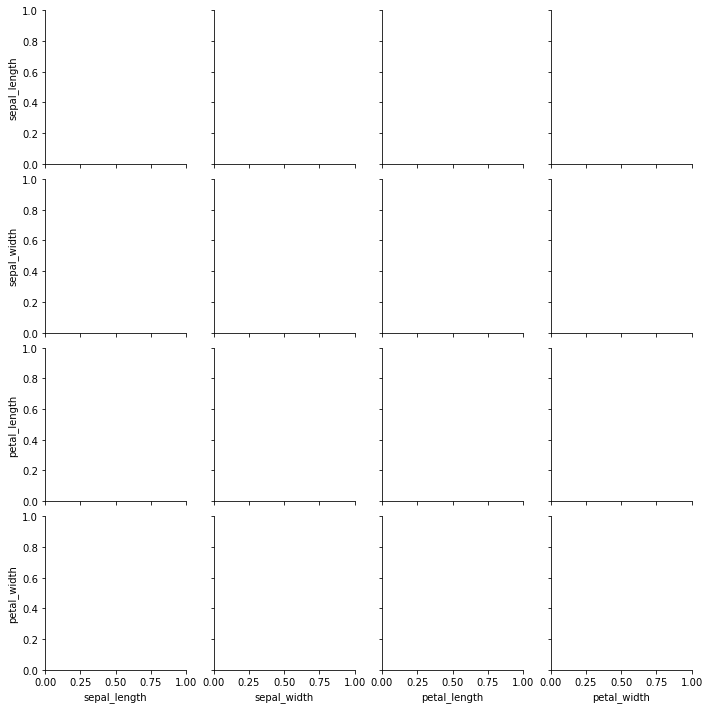

```python
#Just create the grid
sns.PairGrid(iris)
```

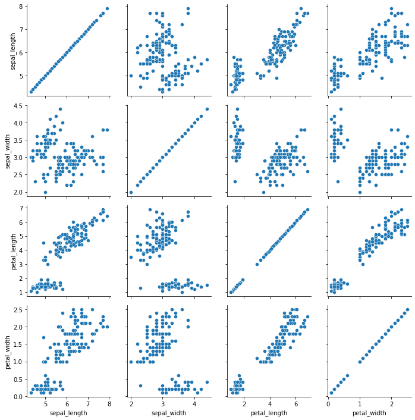

```python
#map the plot on the grid using scatterplot

g = sns.PairGrid(iris)
g.map(sns.scatterplot)
```

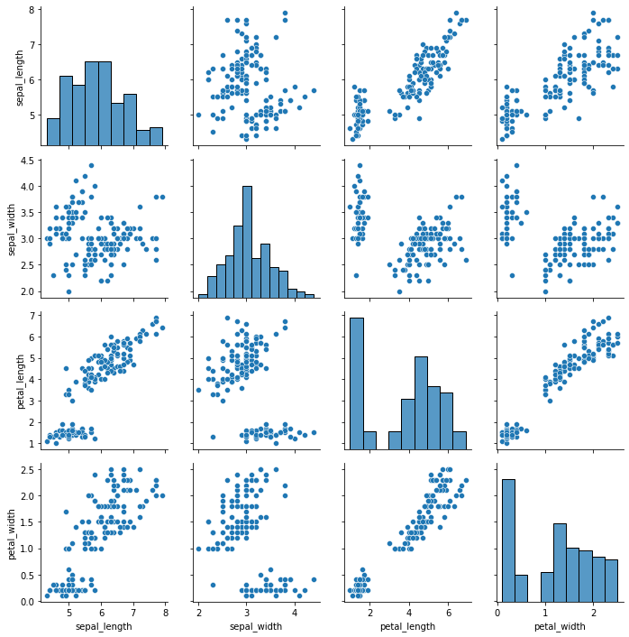

```python
#diagonally histplot() and at others scatterplot()
g = sns.PairGrid(iris)
g.map_diag(sns.histplot)
g.map_offdiag(sns.scatterplot)
```

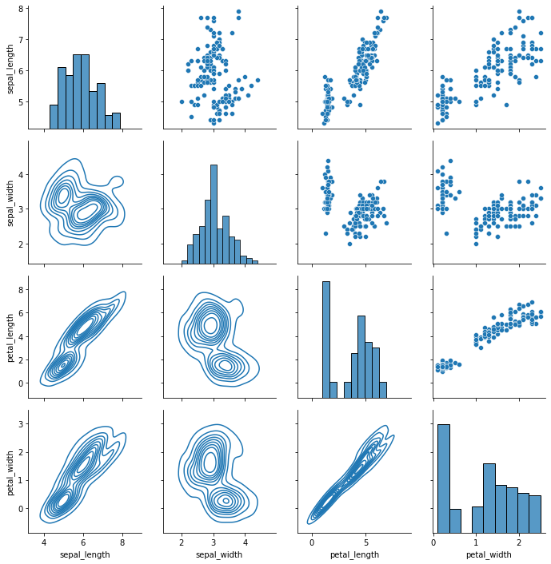

```python
#Different type of plot on the grid
g = sns.PairGrid(iris)
g.map_upper(sns.scatterplot) #scatterplot on the upper
g.map_lower(sns.kdeplot)     # kdeplot on the lower
g.map_diag(sns.histplot)    # histogram on the diagonal
```

## Pairplot

PairGrid is flexible, but to take a quick look at a dataset, it can be easier to use 'pairplot()'.

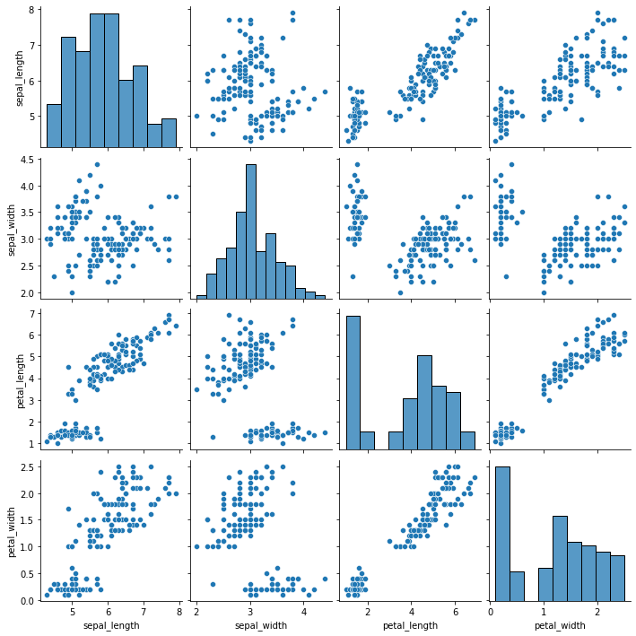

```python
#Creating pairplot with 'iris' dataset
sns.pairplot(iris)
```

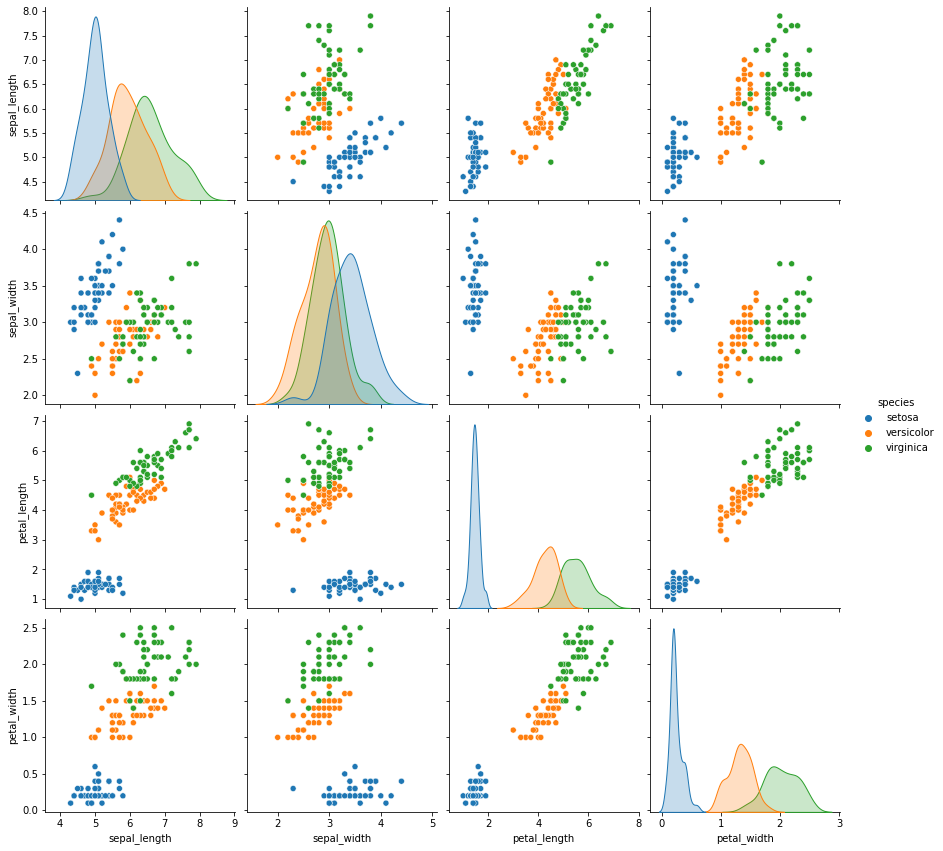

```python
#Creating pairplot with 'iris' dataset and hut set to species
#sns.pairplot(iris,palette='rainbow',hue='species',height=3,diag_kind='kde')
sns.pairplot(iris, hue='species',height=3,diag_kind='kde')
```

## Facet grid

- Facet grid is a generic grid creating approach when you want to use features to create the grid.
- The FacetGrid class is useful when you want to visualize the distribution of a variable or the relationship between multiple variables separately within subsets of your dataset.
- A FacetGrid can be drawn with up to three dimensions: *row, col, and hue*.

```python
#load tips dataset
tips = sns.load_dataset('tips')
tips.head()
```

|  | total_bill | tip | sex | smoker | day | time | size |
| --- | --- | --- | --- | --- | --- | --- | --- |
| 0 | 16.99 | 1.01 | Female | No | Sun | Dinner | 2 |
| 1 | 10.34 | 1.66 | Male | No | Sun | Dinner | 3 |
| 2 | 21.01 | 3.50 | Male | No | Sun | Dinner | 3 |
| 3 | 23.68 | 3.31 | Male | No | Sun | Dinner | 2 |
| 4 | 24.59 | 3.61 | Female | No | Sun | Dinner | 4 |

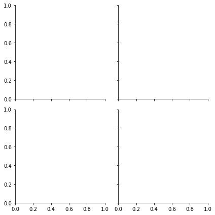

```python
#Create a facetgrid
#two rows: dinner and lunch and two columns for smoker and non-smoker
#sns.FacetGrid(tips,row='time',col='smoker')
sns.FacetGrid(tips,row='time',col='smoker')
```

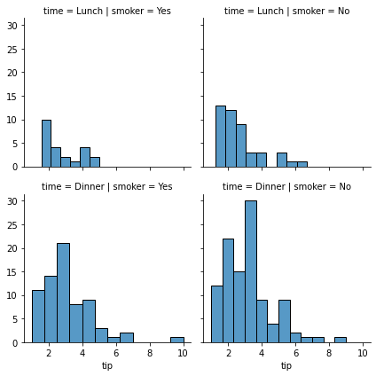

```python
#Create a facetgrid
g = sns.FacetGrid(tips,row='time',col='smoker')
g.map(sns.histplot,'tip')
```

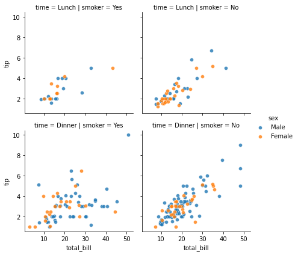

```python
#Create a facetgrid with hue set
# g = sns.FacetGrid(tips,row='time',col='smoker', hue='sex')
# g.map(sns.scatterplot,'total_bill','tip',alpha=0.8)
# g.add_legend()

g= sns.FacetGrid(tips,row='time',col='smoker',hue='sex')
g.map(sns.scatterplot,'total_bill','tip',alpha=0.8)
g.add_legend()
```

### Joinpot

It draws a plot of two variables with bivariate and univariate graphs.

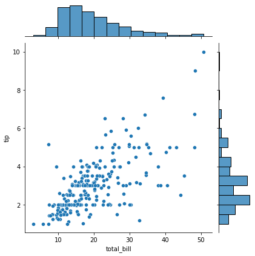

```python
#Jointplot example
sns.jointplot(data=tips,x='total_bill',y='tip')
```

The upper one (histogram) is similar like the below histplot() for *total_bill*

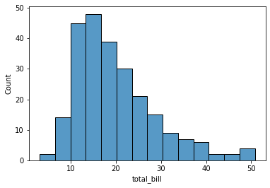

```python
sns.histplot(tips['total_bill'])
```

The right (histogram) one is similar like the below histplot() for *tip*

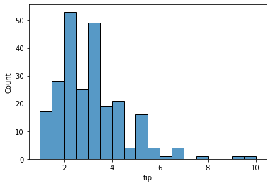

```python
sns.histplot(tips['tip'])
```